# Report

Jacopo Malatesta

21/2/2020

# Goals

This small research aims at gaining insight into the Twitter content concerning the 2020 Democratic Party presidential primaries. The Twitter discourse around this topic has come under a lot of scrutiny in recent times due to the often aggressive behavior of both the candidates and their supporters.

The goal of this research is to analyze Twitter data concerning the four main Democratic candidates in order to highlight the underlying emotion and sentiment beneath their tweets. The candidates whose Tweets were analyzed are Bernie Sanders, Elizabeth Warren, Pete Buttigieg and Joe Biden.

# Reasons behind my choice

The choice of this topic is partly driven by a long-standing interest in American politics and culture, but more importantly by a desire to deepen my knowledge of digital analysis methods and social media in general. After my master degree, I plan on working in the communication and marketing field and in order to be successful in this area acquiring some basic skills in the analysis of social media data is essential. Though I realize that in order to land a good marketing job many more skills need to be added to my talent stack, this small project might turn out to be a good stepping stone in my professional development.

# Main features of the projects

The overall structure of this work was inspired by Céline Van den Rul’s article “A Guide to Mining and Analysing Tweets with R”, which also served as a source of inspiration for many of the lines of codes that were used.

This project consists of three separate steps: collecting the Twitter data, analyzing the content and sentiment of its text and visualizing the results.

The data collection has been carried out by scraping Twitter data with an R studio package called “Rtweet”; the analysis and visualization parts instead required the use of basic text and sentimental analysis tools, such as the syuzhet and tidytext packages. Naturally, more common packages such as rio, dplyr and ggplot2 were used as well throughout the project.

# Technical overview

In this part I’ll go through each step of my project, highlighting its features as well its shortcomings and weaknesses. However, due to the length of some of the chunks of codes, only some lines will be embedded and commented. Readers interested in having a deeper look at the codes can inspect the complete scripts in the scripts folder.

## Packages used

```r
library(dplyr)
library(rtweet)
library(rio)
library(tidytext)
library(quanteda)
```

```r
library(ggplot2)
library(syuzhet)
```

## Data collection

The candidates’ tweets were retrieved with the get_timelines function from the Rtweet package. get_timelines allows users to scrape the most recent 3200 tweets from specific accounts. This feature, albeit useful, lead to the first setback I suffered in this work: since it always retrieves recent tweets, this function retrieves different tweets depending on when it is run. As a result, this project doesn’t produce a fixed and unchanging dataset, thus undermining its reproducibility. So, for example, if a user were to scrape these tweets with this line of code one year from now, he wouldn’t get the same tweets that I’m working on today. As far as I know, the Rtweet package package doesn’t allow users to use the get_timelines function with a specific time interval (the “from” and “until” arguments are only available for the search_tweets function).

The argument n allows me to set the number of tweets to scrape, in this case it was 1000 for each candidate.

```r
overall_tweets <- get_timelines(c("JoeBiden", "PeteButtigieg", "ewarren", "BernieSanders"), n = 1000)

tweets <- import(here::here("output","tweets.csv"))
```

The data were then saved as comma-separated values files, as this is one of the most universal formats available for storing text and data.

## Text pre-processing and text analysis

The text analysis was only conducted on organic tweets, that is tweets that are not retweets.

```r
tweets_organic <- tweets[tweets$is_retweet==FALSE, ]
```

```r
tweets_organic$text <- gsub("https\\S*", "", tweets_organic$text)

tweets_organic$text <- gsub("@\\S*", "", tweets_organic$text)

tweets_organic$text <- gsub("amp", "", tweets_organic$text)

tweets_organic$text <- gsub("[\r\n]", "", tweets_organic$text)

tweets_organic$text <- gsub("[[:punct:]]", "", tweets_organic$text)
```

The next step was using the tidytext package to remove stop words from the words in the text column.

Firstly, I split the text column into different words with the unnest_tokens function.

```r
tweets_cleaned <- tweets_organic %>%
  select(text) %>%
  unnest_tokens(word, text)
```

```r
tweets_cleaned <- tweets_cleaned %>%
  anti_join(stop_words)
```

However, there are still some words left in there that need to be removed. In order to do so, I created a custom list (actually a vector) which I then turned into a dataframe.

```r
custom_list <- c("aapi2020", "ve", "II", "Il", "ll", "lI", "â","iâ", "weâ", "canâ", "itâ", "caign", "hshire", "im", "i'm", "ive", "it's", "chip", "you're", "we're", "fitn", "can't")

custom_df <- tibble(joinColumn = custom_list)

tweets_cleaned <- tweets_cleaned %>%
  anti_join(custom_df,
            by = c("word" = "joinColumn"))
```

After gedding rid of the stop words, I briefly analyzed the text by counting the most frequent words in the candidates’ tweets. I will delve deeper into these results in the final part of this report.

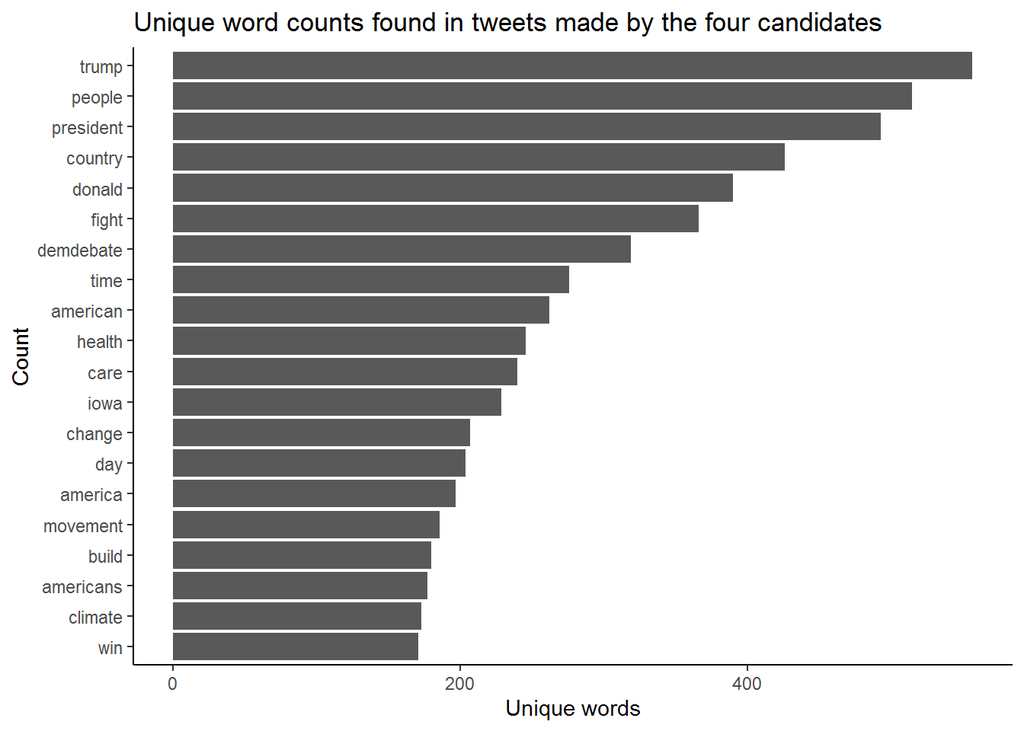

```r
tweets_cleaned %>%
  count(word, sort = TRUE) %>%
  top_n(20) %>%
  mutate(word = reorder(word, n)) %>%
  ggplot(aes(x = word, y = n)) +
  geom_col () +
  xlab(NULL) +
  coord_flip () +
  theme_classic() +
  labs (x = "Count",
        y = "Unique words",
        title = "Unique word counts found in tweets made by the four candidates")
```

## Sentiment analysis

In order to conduct some basic sentiment analysis, I converted the sets of words from UTF-8 to ASCII. Afterwards, I used the get_nrc_sentiment function from the syuzhet package, which calls the NRC sentiment dictionary to calculate the presence of eight different emotions and their corresponding valence in a text file.

```r
tweets_cleaned <- iconv(tweets_cleaned, from="UTF-8", to="ASCII", sub="")

tweets_sentiment <- get_nrc_sentiment((tweets_cleaned))
sentimentscores_tweets <- data.frame(colSums(tweets_sentiment[,]))

names(sentimentscores_tweets) <- "Score"

sentimentscores_tweets <- cbind("sentiment"=rownames(sentimentscores_tweets),sentimentscores_tweets)

rownames(sentimentscores_tweets) <- NULL
```

Finally, I visualize the scores for each emotion with the ggplot2 package.

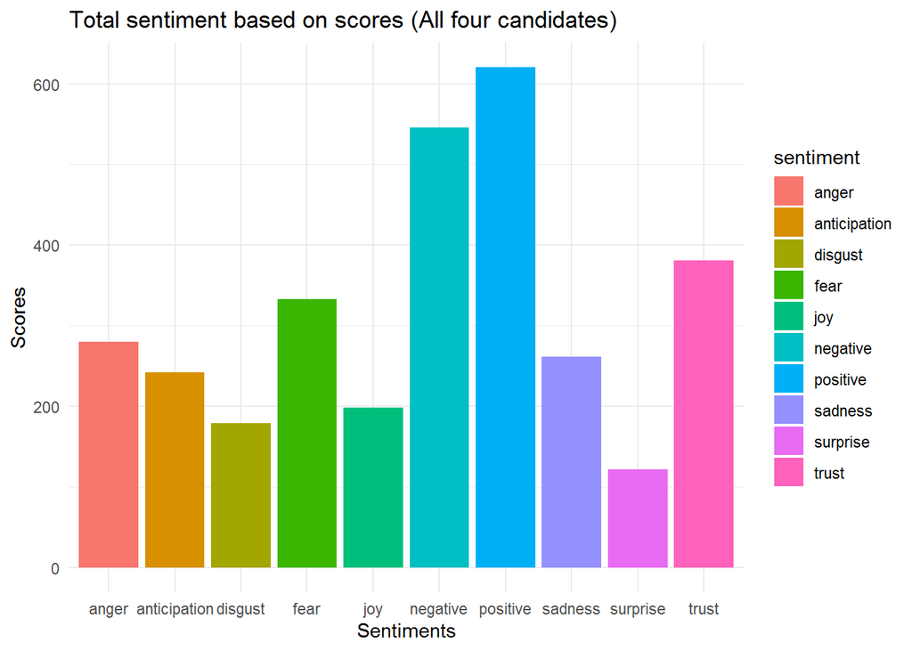

```r
ggplot(data=sentimentscores_tweets,aes(x=sentiment,y=Score))+
  geom_bar(aes(fill=sentiment),stat = "identity")+
  theme(legend.position="none")+
  xlab("Sentiments")+ylab("Scores")+
  ggtitle("Total sentiment based on scores (All four candidates)")+
  theme_minimal()
```